# Classifying Movement

Our goal is to use machine learning techniques to build a model to predict the “classe” category that a particular exercise belongs to based on a set of measurements from the exercise.

First we read in the data which has been pre-classified. Looking at the summary we can see that most of the variables are over 99% missing, so we exclude those variables to reduce the chance of overfitting based on their presence and to allow using techniques that don’t handle missing values well.

```r
library(caret)
library(rpart)
library(plyr)

setwd("~/Code/datasciencecoursera/Machine learning/")
alltrain <- read.csv("pml-training.csv")
#summary(alltrain)
keeptrain <- alltrain[c("roll_belt", "pitch_belt",  "yaw_belt", "total_accel_belt", "gyros_belt_x", "gyros_belt_y", "gyros_belt_z",
    "accel_belt_x", "accel_belt_y", "accel_belt_z", "magnet_belt_x", "magnet_belt_y", "magnet_belt_z",
    "roll_arm", "pitch_arm", "yaw_arm", "total_accel_arm", "gyros_arm_x", "gyros_arm_y", "gyros_arm_z",
    "accel_arm_x", "accel_arm_y", "accel_arm_z", "magnet_arm_x", "magnet_arm_y", "magnet_arm_z",
    "roll_dumbbell", "pitch_dumbbell", "yaw_dumbbell", "total_accel_dumbbell", "gyros_dumbbell_x", "gyros_dumbbell_y", "gyros_dumbbell_z",
    "accel_dumbbell_x", "accel_dumbbell_y", "accel_dumbbell_z", "magnet_dumbbell_x", "magnet_dumbbell_y", "magnet_dumbbell_z",
    "roll_forearm", "pitch_forearm", "yaw_forearm", "total_accel_forearm", "gyros_forearm_x", "gyros_forearm_y", "gyros_forearm_z",
    "accel_forearm_x", "accel_forearm_y", "accel_forearm_z", "magnet_forearm_x", "magnet_forearm_y", "magnet_forearm_z", "classe")]
```

We split the data into training and testing data sets so we can verify our model is not overfitting. Otherwise we would likely have small in-sample errors but very large out-of-sample errors.

```r
set.seed(213)
inTrain <- createDataPartition(keeptrain$classe, p = 0.5,list=FALSE)
training <- keeptrain[inTrain,]
testing <- keeptrain[-inTrain,]
```

We use a recursive parititioning machine learning algorithm to produce a model on the training data set. 5-fold cross-validation is used to keep the algortihm from overfitting. Recursive partitioning has the advantage of being relatively fast for a data set this large.

```r
fitControl <- trainControl( method = "cv", number = 5)
rpartFit <- train(classe ~ ., data = training, method = "rpart", trControl = fitControl)
```

The model can be shown graphically as a decision tree.

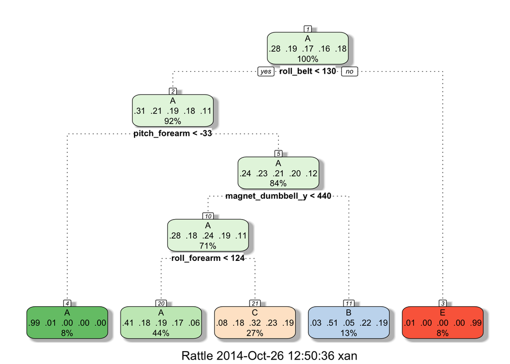

We can compute the in-sample error rate to be about 50% by comparing the predicted classification with the known classifications. Rpart provides probabilities for each classification and row. We use the high probability value as the prediction for that observation.

```r
missClass = function(values,prediction){sum(prediction != values)/length(values)}

predTrain <- predict(rpartFit$finalModel, newdata=training)
bestTrain <- max.col(predTrain)
bestTrainClasse <- mapvalues(bestTrain, from = c(1,2,3,5), to = c("A", "B", "C", "E"))
missClass(training$classe, bestTrainClasse)
```

```
## [1] 0.5075
```

With more time, we would explore other models and tuning values.